# Tutorial: testing microbiome mediation effect using miMediation

Qilin Hong

Last compiled on 25 March, 2024

This is a practical tutorial on the use of `miMediation` package, which introduces a phylogeny-based mediation test (PhyloMed) for high-dimensional microbial composition mediators. The methodology is described in detail in the Hong, Chen, and Tang (2023).

## A brief summary of the PhyloMed

PhyloMed models microbiome mediation effect through a cascade of independent local mediation models of subcompositions on the internal nodes of the phylogenetic tree. Each local model captures the mediation effect of a subcomposition at a given taxonomic resolution. PhyloMed enables us to test the overall mediation effect of the entire microbial community and pinpoint internal nodes with significant subcomposition mediation effects.

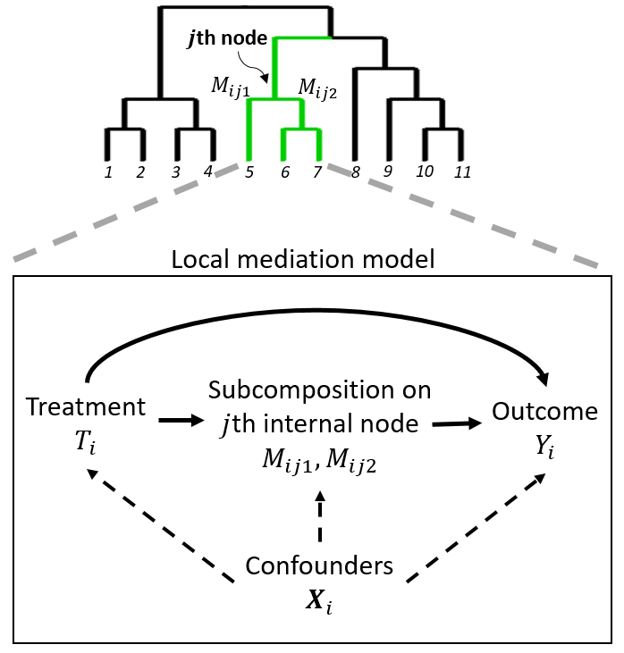

As depicted in the figure above, we propose to construct a local mediation model for the subcomposition at each internal node of the phylogenetic tree. The subcomposition on a given internal node consists of the relative abundance aggregated at its two child nodes. We apply the following robust linear regression model and generalized linear regression model to represent the causal path diagram of the local mediation model at the $j$th internal node
$$E\left\{ \log \left(
\frac{M_{ij1}}{M_{ij2}}\right) \right\} = \alpha^{\rm T}_{jX} {\bf X}_i
+ \alpha_j T_i$$
$$g\{E(Y_i)\} =
\beta^{\rm T}_{jX} {\bf X}_i + \beta_{jT} T_i + \beta_{j}
\log\left(\frac{M_{ij1}}{M_{ij2}}\right)$$
where $g(\cdot)$ is the link function depending on the type of the outcome and we omit the intercept term in both models as it can be absorbed into ${\bf X}_i$.

The local mediation null hypothesis is expressed as
$$H_0^j:\alpha_j\beta_j=0$$
, which is equivalent to the union of three disjoint component null hypotheses

$$\begin{align}
H^{j}_{00}&: \alpha_j = \beta_{j} = 0,\\
H^{j}_{10}&: \alpha_j \neq 0, \beta_{j} = 0,\\
H^{j}_{01}&: \alpha_j = 0, \beta_{j} \neq 0.
\end{align}$$

We define the mediation test statistic for $H_0^j$ as
$$P_{\max_j}=\max(P_{\alpha_j},P_{\beta_j})$$
The $P_{\alpha_j},P_{\beta_j}$ represent the $p$-value for testing $\alpha_j=0$ and $\beta_j=0$, respectively. These two $p$-values could be obtained via asymptotic approach or permutation approach.

Thus, we obtain the $p$-value of mediation test in the $j$th local model using the following formula:
$$Pr(P_{\max_j} \leq p_{\max_j})=\pi_{00}
p^2_{\max_j} + \pi_{10} p_{\max_j} Pr(P_{\alpha_j} \leq p_{\max_j} \mid
\alpha_j \neq 0) + \pi_{01} p_{\max_j} Pr(P_{\beta_j} \leq p_{\max_j}
\mid \beta_j \neq 0)$$
In this formula, we need to estimate three component probabilities ($\pi_{00},\pi_{10},\pi_{01}$) representing the proportion of three null hypotheses ($H^{j}_{00},H^{j}_{10},H^{j}_{01}$). and two power functions evaluated at $p_{\max_j}$. We implement two methods (product, maxp) to estimate $\pi_{00},\pi_{10},\pi_{01}$.

- “product” method: $\hat{\pi}_{00}=\hat{\pi}_{0\bullet}\hat{\pi}_{\bullet0}/\hat{\pi}_0$, $\hat{\pi}_{10}=(1-\hat{\pi}_{0\bullet})\hat{\pi}_{\bullet0}/\hat{\pi}_0$, and $\hat{\pi}_{01}=\hat{\pi}_{0\bullet}(1-\hat{\pi}_{\bullet0})/\hat{\pi}_0$, where $\hat{\pi}_0=\hat{\pi}_{0\bullet} + \hat{\pi}_{\bullet0}-\hat{\pi}_{0\bullet}\hat{\pi}_{\bullet0}$.
- “maxp” method: $\hat{\pi}_{00}=(\hat{\pi}_{0\bullet}+\hat{\pi}_{\bullet0}-\hat{\pi}_0)/\hat{\pi}_0$, $\hat{\pi}_{10}=(\hat{\pi}_0-\hat{\pi}_{0\bullet})/\hat{\pi}_0$, and $\hat{\pi}_{01}=(\hat{\pi}_0-\hat{\pi}_{\bullet0})/\hat{\pi}_0$.

Note that $\hat{\pi}_{0\bullet}, \hat{\pi}_{\bullet0}, \hat{\pi}_0$ are estimated by applying Jin and Cai’s method (Jin and Cai (2007)) to $P_{\alpha_j},P_{\beta_j},P_{\max_j}$. After obtaining the $p$-values on all internal nodes, we apply Benjamini-Hochberg (BH) false discovery rate procedure (Benjamini and Hochberg (1995)) to identify a collection of nodes on the phylogenetic tree with significant mediation effects. To test the global mediation null hypothesis $H_0: \cap_{j=1}^J H^j_0$, we apply the harmonic mean $p$-value (HMP) method (Wilson (2019)) to combine local mediation $p$-values.

## Application with phylognetic information: Cecal data

It is well-known that low dose antibiotics have been used widely to stimulate weight gain in livestock. However, there is growing concern that antibiotic exposure may have long-term consequences. Several studies have shown that antibiotics can have great impact on the abundances of bacteria in the gut community. It is interesting to investigate whether the subtherapeutic antibiotic treatment effect on body weight is mediated through the perturbation of gut microbiome and study the underlying mechanisms.

The data here is from an experiment conducted by Cho et al. (2012), in which young mice were treated by different low-dose antibiotic and evaluated changes in body fat and compositions of the microbiome in cecal and fecal samples. The mice in antibiotic group were heavier than those in the control group. We will show how to perform `phyloMed` function by focusing on cecal samples.

```r
> library(miMediation)
> # Load data
> data(data.cecal)
> # Take a look at the data
> Trt <- data.cecal$treatment
> table(Trt) # 0: control 1: antibotics
Trt
 0  1
10 38
> M <- data.cecal$mediators
> head(M[,1:6])
          3732 5004 4354 4432 3209 5058
cecal_C1     1    2   56   39   12   13
cecal_C10    1    7   60   42   34   31
cecal_C2     9    2   38   40   14    8
cecal_C3     4    4   41   53   16   18
cecal_C4     5    2  102   84   18   19
cecal_C5     5   13   83   62   29   29
> Y <- data.cecal$outcome
> summary(Y)
   Min. 1st Qu.  Median    Mean 3rd Qu.    Max.
  17.20   20.55   21.80   22.32   23.38   32.10
> tree <- data.cecal$tree
```

To run `phyloMed` function, the minimum requirement is to provide `treatment`, `mediators`, `outcome`, `tree` information. In the chunk below, we set FDR = 0.1 (`fdr.alpha=0.1`) in identifying mediating nodes and visualize the results in the tree plot (`graph="rectangular"`). Note that if `n.perm=1e4`, the function will output $p$-value calculated through permutation procedure as well and it will take $\sim 3$ minutes to output the result. In general, permutation procedure can provide more accurate result when sample size is small (e.g., sample size < 100). However, it is slower than asymptotic procedure. You can set `verbose=TRUE` to keep track of the process.

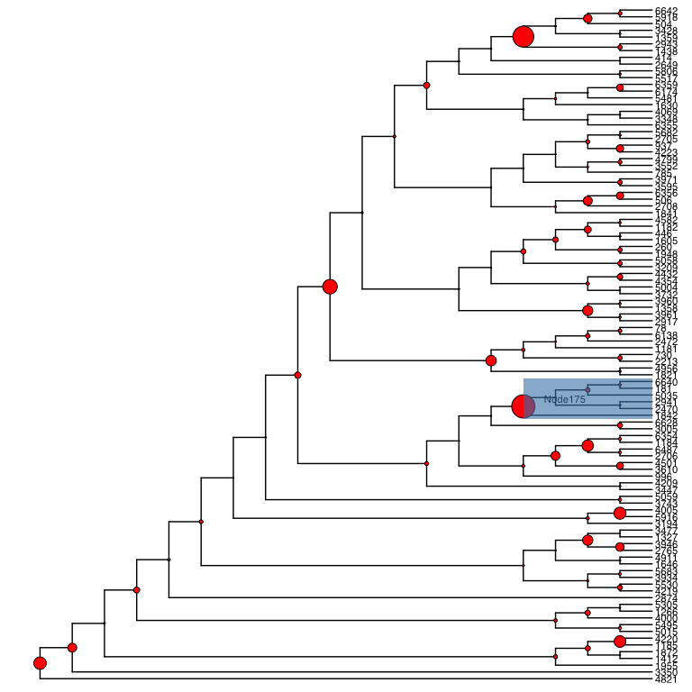

```r
> # set random seed here so that you can get the same result every time you run the code
> set.seed(123)
> cecal.rsltlst <- phyloMed(Trt, M, Y, tree = tree, fdr.alpha = 0.1,
+                           n.perm = 1e4, graph = "rectangular")
Run phyloMed based on phylogenetic tree!
>
> # take a look at phyloseq-class object
> cecal.physeq <- cecal.rsltlst$clean.data
> cecal.physeq
phyloseq-class experiment-level object
otu_table()   OTU Table:         [ 100 taxa and 48 samples ]
sample_data() Sample Data:       [ 48 samples by 2 sample variables ]
phy_tree()    Phylogenetic Tree: [ 100 tips and 99 internal nodes ]
> cecal.rslt <- cecal.rsltlst$rslt
> # take a look at rslt (PhyloMed.P)
> cecal.rslt$PhyloMed.P
$node.pval
    Node101     Node102     Node103     Node104     Node105     Node106
0.030281982 0.087212850 0.785087274 0.201418675 0.621643166 0.398931998
    Node107     Node108     Node109     Node110     Node111     Node112
0.978139609 0.854379789 0.189859663 0.016098017 0.744129812 0.802090213
    Node113     Node114     Node115     Node116     Node117     Node118
0.982453199 0.420754447 0.919106969 0.249736872 0.256278130 0.382368257
    Node119     Node120     Node121     Node122     Node123     Node124
0.258854190 0.172234807 0.718848156 0.601642392 0.362137412 0.068381195
    Node125     Node126     Node127     Node128     Node129     Node130
0.656538756 0.641171215 0.524807997 0.922249833 0.912876455 0.888669021
    Node131     Node132     Node133     Node134     Node135     Node136
0.792296692 0.353887654 0.378420707 0.147483826 0.678061992 0.291097804
    Node137     Node138     Node139     Node140     Node141     Node142
0.735532041 0.088049675 0.157337728 0.198011861 0.775650836 0.647922241
    Node143     Node144     Node145     Node146     Node147     Node148
0.843456006          NA 0.002121006 0.387749092 0.812096288 0.704785157
    Node149     Node150     Node151     Node152     Node153     Node154
0.110456597 0.417617649 0.780344203 0.676221278 0.912876455 0.154203674
    Node155     Node156     Node157     Node158     Node159     Node160
0.894615983 0.838084609 0.053767158 0.441361251 0.832772308 0.401819283
    Node161     Node162     Node163     Node164     Node165     Node166
0.389802395 0.366394584 0.678061992 0.363950851 0.802090213 0.931790679
    Node167     Node168     Node169     Node170     Node171     Node172
0.522471300 0.091543278 0.066833947 0.508831832 0.522471300 0.144818515
    Node173     Node174     Node175     Node176     Node177     Node178
0.958083964 0.283995758 0.000834879 0.814631773 0.335736433 0.612268401
    Node179     Node180     Node181     Node182     Node183     Node184
0.687398972 0.486436564 0.534343639 0.033309751 0.679911520 0.634543086
    Node185     Node186     Node187     Node188     Node189     Node190
0.285157167 0.546704499 0.944779576 0.854379789 0.066696399 0.113809008
    Node191     Node192     Node193     Node194     Node195     Node196
0.958083964 0.506620196 0.507723866 0.267913114 0.888669021 0.358559400
    Node197     Node198     Node199
0.296433343 0.859934069 0.036027716

$sig.clade
$sig.clade$Node175
[1] "2470" "2941" "181"  "6640" "5035" "1842"


$null.prop
       H00        H10        H01
0.59817608 0.36254122 0.03928271

$global.pval
       HMP
0.06854347
```

The output consists of four components:

- `node.pval`: mediation $p$-values on each internal node of the phylogenetic tree.
- `sig.clade`: identified mediation node ids with their corresponding leaf-level descendant taxa name.
- `null.prop`: estimated proportion of three disjoint component null hypotheses.
- `global.pval`: global test $p$-value.

Note that p-value is NA at internal node 144. If we set `verbose=TRUE`, we could know the reason during the process. The underlying reason is that all values in the treatment variable equal to one after removing the subjects with subcomposition being zero. Thus, we skip this specific node.

In the figure above, the size of the circle on internal node is proportional to $-\log_{10}(\text{subcompostion mediation p-value }p_j)$, where $p_j$ lives in the `node.pval` output. The identified mediation node is highlighted by a blue rectangle.

## Application with taxonomic information: ZeeviD data

When there is no phylogenetic information available, the `phyloMed` function could construct taxonomic tree based on the taxonomy table. The `data.zeeviD` is a simulated dataset based on a real gut microbiome dataset from a healthy cohort (Zeevi et al. (2015)). The mediation signal was added at “Order.Clostridiales”.

```r
> # Load data
> data(data.zeeviD)
> # Take a look at the data
> Trt <- data.zeeviD$treatment
> table(Trt) # 0: control 1: treatment
Trt
  0   1
200 200
> M <- data.zeeviD$mediators
> dim(M)
[1] 400 100
> Y <- data.zeeviD$outcome
> summary(Y)
    Min.  1st Qu.   Median     Mean  3rd Qu.     Max.
-238.401 -113.996  -58.528  -60.717   -6.791  183.129
> tree <- data.zeeviD$tree
> head(tree)
Taxonomy Table:     [6 taxa by 7 taxonomic ranks]:
                                       Kingdom    Phylum       Class
s__Megamonas_hypermegale               "Bacteria" "Firmicutes" "Negativicutes"
s__Megamonas_funiformis                "Bacteria" "Firmicutes" "Negativicutes"
s__Megamonas_rupellensis               "Bacteria" "Firmicutes" "Negativicutes"
s__Phascolarctobacterium_succinatutens "Bacteria" "Firmicutes" "Negativicutes"
s__Dialister_succinatiphilus           "Bacteria" "Firmicutes" "Negativicutes"
s__Ruminococcus_bromii                 "Bacteria" "Firmicutes" "Clostridia"
                                       Order             Family
s__Megamonas_hypermegale               "Selenomonadales" "Veillonellaceae"
s__Megamonas_funiformis                "Selenomonadales" "Veillonellaceae"
s__Megamonas_rupellensis               "Selenomonadales" "Veillonellaceae"
s__Phascolarctobacterium_succinatutens "Selenomonadales" "Acidaminococcaceae"
s__Dialister_succinatiphilus           "Selenomonadales" "Veillonellaceae"
s__Ruminococcus_bromii                 "Clostridiales"   "Ruminococcaceae"
                                       Genus
s__Megamonas_hypermegale               "Megamonas"
s__Megamonas_funiformis                "Megamonas"
s__Megamonas_rupellensis               "Megamonas"
s__Phascolarctobacterium_succinatutens "Phascolarctobacterium"
s__Dialister_succinatiphilus           "Dialister"
s__Ruminococcus_bromii                 "Ruminococcus"
                                       Species
s__Megamonas_hypermegale               "Megamonas_hypermegale"
s__Megamonas_funiformis                "Megamonas_funiformis"
s__Megamonas_rupellensis               "Megamonas_rupellensis"
s__Phascolarctobacterium_succinatutens "Phascolarctobacterium_succinatutens"
s__Dialister_succinatiphilus           "Dialister_succinatiphilus"
s__Ruminococcus_bromii                 "Ruminococcus_bromii"
```

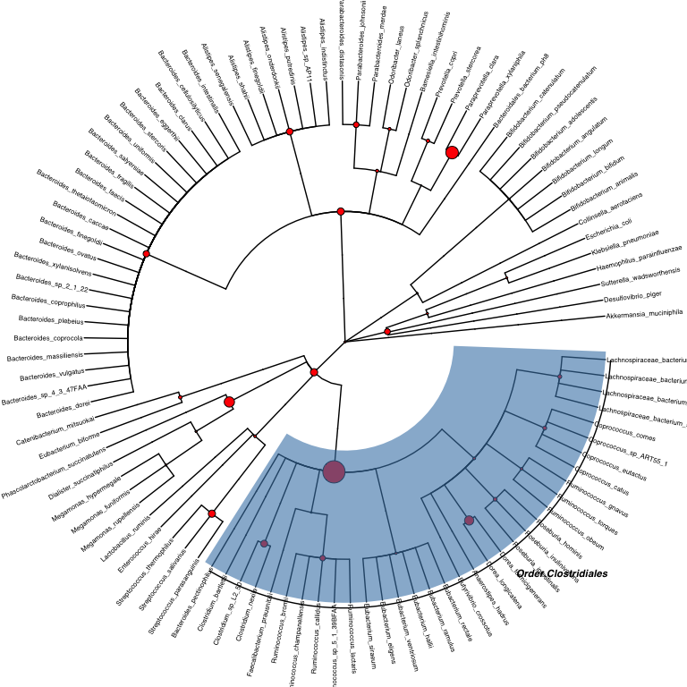

```r
> # run asymptotic result by default
> demo.rsltlst <- phyloMed(Trt, M, Y, tree = tree,
+                          fdr.alpha = 0.1, graph = "circular")
No phylogenetic tree available, construct taxonomic tree!
> # take a look at phyloseq-class object
> demo.physeq <- demo.rsltlst$clean.data
> demo.physeq
phyloseq-class experiment-level object
otu_table()   OTU Table:         [ 100 taxa and 400 samples ]
sample_data() Sample Data:       [ 400 samples by 2 sample variables ]
tax_table()   Taxonomy Table:    [ 100 taxa by 7 taxonomic ranks ]
> demo.rsltlst$rslt$PhyloMed.A
$node.pval
             Genus.Alistipes            Genus.Bacteroides
                 0.170003884                  0.186275052
       Genus.Bifidobacterium                Genus.Blautia
                 0.781201593                  0.576986566
           Genus.Clostridium            Genus.Coprococcus
                 0.163289948                  0.394528854
                 Genus.Dorea            Genus.Eubacterium
                 0.079844820                  0.634174237
Genus.Lachnospiraceae_noname              Genus.Megamonas
                 0.385521850                  0.757961853
           Genus.Odoribacter        Genus.Parabacteroides
                 0.507963359                  0.232969190
        Genus.Paraprevotella             Genus.Prevotella
                 0.029002277                  0.435270744
             Genus.Roseburia           Genus.Ruminococcus
                 0.416151196                  0.244208259
         Genus.Streptococcus    Family.Enterobacteriaceae
                 0.147477523                  0.751206698
  Family.Erysipelotrichaceae       Family.Lachnospiraceae
                 0.449547728                  0.571919231
   Family.Porphyromonadaceae        Family.Prevotellaceae
                 0.496710495                  0.988395637
      Family.Ruminococcaceae       Family.Veillonellaceae
                 0.828254477                  0.727099201
         Order.Bacteroidales          Order.Clostridiales
                 0.147080796                  0.001585361
       Order.Lactobacillales        Order.Selenomonadales
                 0.576675904                  0.058233749
        Class.Actinobacteria    Class.Gammaproteobacteria
                 0.789683999                  0.673106970
           Phylum.Firmicutes        Phylum.Proteobacteria
                 0.142161075                  0.217352633
            Kingdom.Bacteria
                 0.700154726

$sig.clade
$sig.clade$Order.Clostridiales
 [1] "Ruminococcus_bromii"                 "Faecalibacterium_prausnitzii"
 [3] "Eubacterium_siraeum"                 "Ruminococcus_champanellensis"
 [5] "Ruminococcus_callidus"               "Coprococcus_catus"
 [7] "Butyrivibrio_crossotus"              "Eubacterium_eligens"
 [9] "Bacteroides_pectinophilus"           "Eubacterium_ventriosum"
[11] "Clostridium_sp_L2_50"                "Coprococcus_eutactus"
[13] "Coprococcus_sp_ART55_1"              "Eubacterium_hallii"
[15] "Lachnospiraceae_bacterium_5_1_63FAA" "Anaerostipes_hadrus"
[17] "Eubacterium_ramulus"                 "Eubacterium_rectale"
[19] "Roseburia_intestinalis"              "Roseburia_inulinivorans"
[21] "Roseburia_hominis"                   "Ruminococcus_obeum"
[23] "Ruminococcus_sp_5_1_39BFAA"          "Clostridium_nexile"
[25] "Coprococcus_comes"                   "Dorea_longicatena"
[27] "Dorea_formicigenerans"               "Ruminococcus_lactaris"
[29] "Lachnospiraceae_bacterium_1_1_57FAA" "Lachnospiraceae_bacterium_8_1_57FAA"
[31] "Ruminococcus_torques"                "Lachnospiraceae_bacterium_3_1_46FAA"
[33] "Ruminococcus_gnavus"                 "Clostridium_bartlettii"


$null.prop
      H00       H10       H01
0.3316206 0.1427697 0.5256097

$global.pval
       HMP
0.05735723
```

## References

Benjamini, Yoav, and Yosef Hochberg. 1995. “Controlling the False Discovery Rate: A Practical and Powerful Approach to Multiple Testing.” *Journal of the Royal Statistical Society: Series B (Methodological)* 57 (1): 289–300.

Cho, Ilseung, Shingo Yamanishi, Laura Cox, Barbara A Methé, Jiri Zavadil, Kelvin Li, Zhan Gao, et al. 2012. “Antibiotics in Early Life Alter the Murine Colonic Microbiome and Adiposity.” *Nature* 488 (7413): 621–26.

Hong, Qilin, Guanhua Chen, and Zheng-Zheng Tang. 2023. “PhyloMed: A Phylogeny-Based Test of Mediation Effect in Microbiome.” *Genome Biology* 24 (1): 72.

Jin, Jiashun, and T Tony Cai. 2007. “Estimating the Null and the Proportion of Nonnull Effects in Large-Scale Multiple Comparisons.” *Journal of the American Statistical Association* 102 (478): 495–506.

Wilson, Daniel J. 2019. “The Harmonic Mean p-Value for Combining Dependent Tests.” *Proceedings of the National Academy of Sciences* 116 (4): 1195–1200.

Zeevi, David, Tal Korem, Niv Zmora, David Israeli, Daphna Rothschild, Adina Weinberger, Orly Ben-Yacov, et al. 2015. “Personalized Nutrition by Prediction of Glycemic Responses.” *Cell* 163 (5): 1079–94.